# Zeal panel: Inv4m effect on flowering time (NC2025)

Fausto Rodríguez

2026-05-15

## Goal

Test whether the *Inv4m* introgression affects flowering time (DTS, DTA) in the BZea NIL panel grown at NC2025 (raw data: `data/CLY25_ZEAL.csv`, provided by Hannah Pil; spatial correction applied upstream).

`Inv4m` is recoded `recurrent` (B73 haplotype) vs `donor` (teosinte haplotype) so the fixed-effect coefficient reads as the *donor − recurrent* contrast.

## Data prep

```r
corr <- read.csv(file.path(paths$data, "CLY25_ZEAL.csv"),  stringsAsFactors = FALSE)
meta <- read.csv(file.path(paths$data, "Bzea_metadata.csv"), stringsAsFactors = FALSE)

OUTLIER_PLOTS <- c(2756, 453, 304)   # Hannah's outlier list

df_full <- corr |>
  filter(!Plot %in% OUTLIER_PLOTS) |>
  rename(NIL = Genotype) |>
  filter(!NIL %in% c("B73", "Purple Check"), !is.na(NIL)) |>
  filter(inv4m_introgression %in% c("yes", "no")) |>
  mutate(
    Inv4m     = factor(
      ifelse(inv4m_introgression == "yes", "donor", "recurrent"),
      levels = c("recurrent", "donor")
    ),
    accession = substr(NIL, 1,  7),
    f1        = substr(NIL, 1, 10),
    bc1       = substr(NIL, 1, 13),
    bc2       = substr(NIL, 1, 16),
    taxon_L1  = case_when(
      grepl("^Zea mays",          meta$species[match(accession, meta$donor_id)]) ~ "Z_mays",
      grepl("^Zea luxurians",     meta$species[match(accession, meta$donor_id)]) ~ "Z_luxurians",
      grepl("^Zea diploperennis", meta$species[match(accession, meta$donor_id)]) ~ "Z_diploperennis"
    ),
    taxon_L2  = meta$species[match(accession, meta$donor_id)]
  ) |>
  select(-species) |>
  left_join(meta |> select(donor_id, ancestry = race),
            by = c("accession" = "donor_id"))

both_arms_bc1 <- df_full |>
  distinct(bc1, Inv4m) |>
  count(bc1) |>
  filter(n == 2) |>
  pull(bc1)
df <- df_full |> filter(bc1 %in% both_arms_bc1)

cat(sprintf("plots: %d  |  bc1 families: %d  |  bc2 families: %d  |  NILs: %d\n",
            nrow(df),
            dplyr::n_distinct(df$bc1),
            dplyr::n_distinct(df$bc2),
            dplyr::n_distinct(df$NIL)))
```

```
## plots: 397  |  bc1 families: 35  |  bc2 families: 100  |  NILs: 217
```

## Model selection

A note on terminology: the `Bzea_metadata.csv` file stores the maize germplasm grouping in a column named `race`. Throughout this notebook that column is renamed to `ancestry` on join, following current convention in human and increasingly in plant genetics literature where “race” is avoided. The two terms refer to the same field; the rename is cosmetic.

The candidate hierarchy (top → bottom):

```
taxon_L1 (Zea species)
  └─ taxon_L2 (subspecies / species)
       └─ ancestry (race column)
            └─ accession (donor germplasm)
                 └─ f1
                      └─ bc1
                           └─ bc2
                                └─ NIL (full pedigree string)
                                     └─ replicate plots
```

A first decision is which levels carry enough variance contrast to be identifiable. Two checks: per-level group counts (a level with <5 groups won’t yield a credible variance estimate) and how many groups have **both** inv4m arms (without that, the level can’t be separated from the Inv4m fixed effect).

### Per-level diagnostic

```r
levels_to_check <- c("taxon_L1", "taxon_L2", "ancestry",
                     "accession", "f1", "bc1", "bc2", "NIL")

summarise_level <- function(col) {
  tab <- table(df[[col]])
  arms <- df |>
    distinct(.data[[col]], Inv4m) |>
    count(.data[[col]]) |>
    pull(n)
  data.frame(
    level         = col,
    n_groups      = length(tab),
    plots_min     = min(tab),
    plots_med     = median(tab),
    plots_max     = max(tab),
    groups_w_both_arms = sum(arms == 2)
  )
}
diag_tbl <- do.call(rbind, lapply(levels_to_check, summarise_level))
kable(diag_tbl, caption = "Per-level group counts and inv4m arm coverage")
```

Per-level group counts and inv4m arm coverage

| level | n_groups | plots_min | plots_med | plots_max | groups_w_both_arms |
| --- | --- | --- | --- | --- | --- |
| taxon_L1 | 1 | 397 | 397.0 | 397 | 1 |
| taxon_L2 | 2 | 37 | 198.5 | 360 | 2 |
| ancestry | 5 | 19 | 49.0 | 162 | 5 |
| accession | 18 | 3 | 9.0 | 73 | 18 |
| f1 | 21 | 3 | 10.0 | 63 | 21 |
| bc1 | 35 | 3 | 8.0 | 35 | 35 |
| bc2 | 100 | 1 | 4.0 | 8 | 29 |
| NIL | 217 | 1 | 2.0 | 2 | 0 |

### Full slash-nested fit (6 random effects)

Fit the full nested structure first to see which intermediates carry identifiable variance.

```r
fit_one <- function(trait, formula_str, label) {
  f <- as.formula(paste(trait, "~", formula_str))
  m <- suppressMessages(lmerTest::lmer(f, data = df))
  fe <- summary(m)$coefficients["Inv4mdonor", ]
  ci <- confint(m, parm = "Inv4mdonor", method = "Wald")
  list(model = m, trait = trait, label = label,
       estimate = unname(fe["Estimate"]),
       se       = unname(fe["Std. Error"]),
       df       = unname(fe["df"]),
       t        = unname(fe["t value"]),
       p        = unname(fe["Pr(>|t|)"]),
       ci_lo    = ci[1, 1],
       ci_hi    = ci[1, 2],
       singular = lme4::isSingular(m),
       vc       = as.data.frame(VarCorr(m)))
}

TRAITS <- c("DTA_corr", "DTS_corr", "PH_corr")

full_re <- "Inv4m + (1 | ancestry / accession / f1 / bc1 / bc2 / NIL)"
full_fits <- lapply(TRAITS, fit_one,
                    formula_str = full_re, label = "full 6-RE slash")
names(full_fits) <- TRAITS

for (tr in names(full_fits)) {
  f <- full_fits[[tr]]
  cat(sprintf("\n%s   isSingular = %s\n", tr, f$singular))
  vc <- f$vc; vc$pct <- round(100 * vc$vcov / sum(vc$vcov), 1)
  print(vc[, c("grp", "vcov", "sdcor", "pct")], row.names = FALSE)
}
```

```
##
## DTA_corr   isSingular = TRUE
##                                grp      vcov     sdcor  pct
##  NIL:bc2:bc1:f1:accession:ancestry 1.7602317 1.3267373 42.8
##      bc2:bc1:f1:accession:ancestry 0.1229952 0.3507068  3.0
##          bc1:f1:accession:ancestry 0.0000000 0.0000000  0.0
##              f1:accession:ancestry 0.0000000 0.0000000  0.0
##                 accession:ancestry 0.0000000 0.0000000  0.0
##                           ancestry 1.1360216 1.0658431 27.6
##                           Residual 1.0969471 1.0473524 26.6
##
## DTS_corr   isSingular = TRUE
##                                grp      vcov     sdcor  pct
##  NIL:bc2:bc1:f1:accession:ancestry 2.4672184 1.5707382 49.5
##      bc2:bc1:f1:accession:ancestry 0.2511773 0.5011759  5.0
##          bc1:f1:accession:ancestry 0.0000000 0.0000000  0.0
##              f1:accession:ancestry 0.0000000 0.0000000  0.0
##                 accession:ancestry 0.0000000 0.0000000  0.0
##                           ancestry 1.1661758 1.0798962 23.4
##                           Residual 1.1025810 1.0500386 22.1
##
## PH_corr   isSingular = TRUE
##                                grp         vcov      sdcor  pct
##  NIL:bc2:bc1:f1:accession:ancestry 172.06825192 13.1174789 49.8
##      bc2:bc1:f1:accession:ancestry  34.79607596  5.8988199 10.1
##          bc1:f1:accession:ancestry   0.03459036  0.1859848  0.0
##              f1:accession:ancestry   4.05678546  2.0141463  1.2
##                 accession:ancestry   0.00000000  0.0000000  0.0
##                           ancestry  40.32264898  6.3500117 11.7
##                           Residual  94.29462706  9.7105421 27.3
```

### Parsimonious model

Drop the three zero-variance levels:

```r
parsim_re <- "Inv4m + (1 | ancestry / bc2 / NIL)"
parsim_fits <- lapply(TRAITS, fit_one,
                      formula_str = parsim_re, label = "parsimonious 3-RE slash")
names(parsim_fits) <- TRAITS

for (tr in names(parsim_fits)) {
  f <- parsim_fits[[tr]]
  cat(sprintf("\n%s   isSingular = %s\n", tr, f$singular))
  vc <- f$vc; vc$pct <- round(100 * vc$vcov / sum(vc$vcov), 1)
  print(vc[, c("grp", "vcov", "sdcor", "pct")], row.names = FALSE)
  cat(sprintf("Inv4m (donor - recurrent) = %+.3f d   SE = %.3f   95%% CI [%+.3f, %+.3f]   p = %.4g\n",
              f$estimate, f$se, f$ci_lo, f$ci_hi, f$p))
}
```

```
##
## DTA_corr   isSingular = FALSE
##               grp      vcov     sdcor  pct
##  NIL:bc2:ancestry 1.7602386 1.3267398 42.8
##      bc2:ancestry 0.1229911 0.3507009  3.0
##          ancestry 1.1360269 1.0658456 27.6
##          Residual 1.0969457 1.0473518 26.6
## Inv4m (donor - recurrent) = -0.613 d   SE = 0.266   95% CI [-1.134, -0.092]   p = 0.02211
##
## DTS_corr   isSingular = FALSE
##               grp      vcov     sdcor  pct
##  NIL:bc2:ancestry 2.4672208 1.5707389 49.5
##      bc2:ancestry 0.2511609 0.5011596  5.0
##          ancestry 1.1662639 1.0799370 23.4
##          Residual 1.1025834 1.0500397 22.1
## Inv4m (donor - recurrent) = -0.881 d   SE = 0.306   95% CI [-1.481, -0.281]   p = 0.004384
##
## PH_corr   isSingular = FALSE
##               grp      vcov     sdcor  pct
##  NIL:bc2:ancestry 171.23836 13.085807 49.4
##      bc2:ancestry  38.71001  6.221737 11.2
##          ancestry  42.56949  6.524530 12.3
##          Residual  94.27612  9.709589 27.2
## Inv4m (donor - recurrent) = +1.606 d   SE = 2.681   95% CI [-3.649, +6.860]   p = 0.5498
```

### Sanity check: equivalent flat formulation

`(1 | ancestry / bc2 / NIL)` is mathematically identical to `(1|ancestry) + (1|bc2) + (1|bc2:NIL)` because the IDs are globally unique (each `bc2` belongs to one `ancestry`; each `NIL` belongs to one `bc2`). The slash form is preferred because it makes the nesting visible in the formula itself.

```r
flat_re   <- "Inv4m + (1|ancestry) + (1|bc2) + (1|bc2:NIL)"
flat_fits <- lapply(TRAITS, fit_one,
                    formula_str = flat_re, label = "parsim flat")
names(flat_fits) <- TRAITS

cmp <- bind_rows(
  lapply(TRAITS, function(tr)
    tibble(trait = tr,
           form  = c("full slash (6 RE)",
                     "parsim slash (3 RE)",
                     "parsim flat (3 RE)"),
           est   = c(full_fits[[tr]]$estimate, parsim_fits[[tr]]$estimate,
                     flat_fits[[tr]]$estimate),
           se    = c(full_fits[[tr]]$se,       parsim_fits[[tr]]$se,
                     flat_fits[[tr]]$se),
           singular = c(full_fits[[tr]]$singular, parsim_fits[[tr]]$singular,
                        flat_fits[[tr]]$singular)))
)
kable(cmp, digits = 4, caption = "Inv4m fixed effect across three formulations")
```

Inv4m fixed effect across three formulations

| trait | form | est | se | singular |
| --- | --- | --- | --- | --- |
| DTA_corr | full slash (6 RE) | -0.6129 | 0.2659 | TRUE |
| DTA_corr | parsim slash (3 RE) | -0.6129 | 0.2659 | FALSE |
| DTA_corr | parsim flat (3 RE) | -0.6129 | 0.2659 | FALSE |
| DTS_corr | full slash (6 RE) | -0.8811 | 0.3060 | TRUE |
| DTS_corr | parsim slash (3 RE) | -0.8811 | 0.3060 | FALSE |
| DTS_corr | parsim flat (3 RE) | -0.8811 | 0.3060 | FALSE |
| PH_corr | full slash (6 RE) | 1.6244 | 2.6793 | TRUE |
| PH_corr | parsim slash (3 RE) | 1.6057 | 2.6810 | FALSE |
| PH_corr | parsim flat (3 RE) | 1.6057 | 2.6810 | FALSE |

**Canonical model (used downstream):**

$$\texttt{trait} \sim \text{Inv4m} + (1 \mid \text{ancestry} / \text{bc2}
/ \text{NIL})$$

```r
fits <- parsim_fits   # downstream chunks reference `fits`
```

### Where does the variance live?

A natural follow-up: are `bc1`/`bc2` effects “absorbed into ancestry”? To check, refit the parsimonious model dropping either `ancestry` or `bc2`. If they were fighting for the same variance, the survivor would grow to compensate.

```r
vc_table <- function(formula_str, label) {
  m <- suppressMessages(lmerTest::lmer(
    as.formula(paste("DTS_corr ~", formula_str)), data = df))
  vc <- as.data.frame(VarCorr(m))
  vc$pct <- round(100 * vc$vcov / sum(vc$vcov), 1)
  vc$model <- label
  vc[, c("model", "grp", "vcov", "pct")]
}

bind_rows(
  vc_table("Inv4m + (1 | ancestry / bc2 / NIL)",  "ancestry + bc2 + NIL  (canonical)"),
  vc_table("Inv4m + (1 | ancestry) + (1 | NIL)",  "ancestry + NIL  (no bc2)"),
  vc_table("Inv4m + (1 | bc2 / NIL)",         "bc2 + NIL   (no ancestry)")
) |>
  pivot_wider(id_cols = grp, names_from = model, values_from = pct,
              values_fill = 0) |>
  kable(caption = "Variance components (% of total) for DTS_corr under three nestings")
```

Variance components (% of total) for DTS_corr under three nestings

| grp | ancestry + bc2 + NIL (canonical) | ancestry + NIL (no bc2) | bc2 + NIL (no ancestry) |
| --- | --- | --- | --- |
| NIL:bc2:ancestry | 49.5 | 0.0 | 0.0 |
| bc2:ancestry | 5.0 | 0.0 | 0.0 |
| ancestry | 23.4 | 23.3 | 0.0 |
| Residual | 22.1 | 22.2 | 24.7 |
| NIL | 0.0 | 54.5 | 0.0 |
| NIL:bc2 | 0.0 | 0.0 | 55.8 |
| bc2 | 0.0 | 0.0 | 19.5 |

## Permutation test

Permute the `Inv4m` label within each `bc2` family (the finest pedigree level in the model) so the null preserves the nested structure. 1000 iterations per trait.

```r
permute_within_bc2 <- function(d) {
  d |> group_by(bc2) |> mutate(Inv4m = sample(Inv4m)) |> ungroup()
}

perm_test <- function(trait, n_perm = 1000) {
  observed <- fits[[trait]]$estimate
  f <- as.formula(paste(trait, "~ Inv4m + (1 | ancestry / bc2 / NIL)"))
  null_coefs <- numeric(n_perm)
  for (i in seq_len(n_perm)) {
    d_perm <- permute_within_bc2(df)
    m_perm <- suppressMessages(suppressWarnings(lme4::lmer(f, data = d_perm)))
    null_coefs[i] <- fixef(m_perm)["Inv4mdonor"]
  }
  p_perm <- (sum(abs(null_coefs) >= abs(observed)) + 1) / (n_perm + 1)
  list(observed = observed, null = null_coefs, p_perm = p_perm)
}

perms <- lapply(names(fits), perm_test, n_perm = 1000)
names(perms) <- names(fits)

for (tr in names(perms)) {
  cat(sprintf("%s: permutation p (1000 within-bc2 perms) = %.4g\n",
              tr, perms[[tr]]$p_perm))
}
```

```
## DTA_corr: permutation p (1000 within-bc2 perms) = 0.005994
## DTS_corr: permutation p (1000 within-bc2 perms) = 0.000999
## PH_corr: permutation p (1000 within-bc2 perms) = 0.3257
```

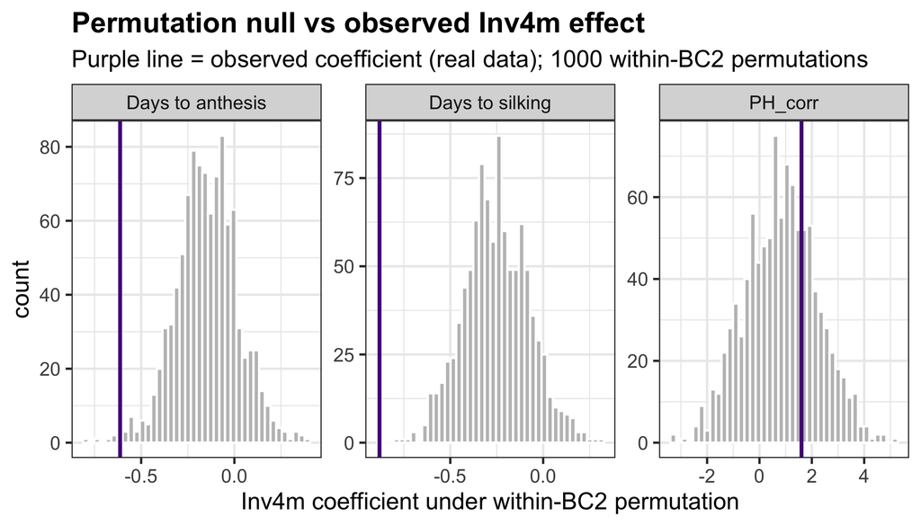

```r
null_df <- bind_rows(lapply(names(perms), function(tr) {
  tibble(trait    = tr,
         null     = perms[[tr]]$null,
         observed = perms[[tr]]$observed)
})) |>
  mutate(trait_label = recode(trait,
                              DTS_corr = "Days to silking",
                              DTA_corr = "Days to anthesis"))

p_null <- ggplot(null_df, aes(x = null)) +
  geom_histogram(bins = 40, fill = "grey75", color = "white") +
  geom_vline(aes(xintercept = observed), color = "#551a8b", linewidth = 1) +
  facet_wrap(~ trait_label, scales = "free") +
  labs(x = "Inv4m coefficient under within-BC2 permutation",
       y = "count",
       title = "Permutation null vs observed Inv4m effect",
       subtitle = "Purple line = observed coefficient (real data); 1000 within-BC2 permutations") +
  theme_bw(base_size = 13) +
  theme(plot.title = element_text(face = "bold"))
print(p_null)
```

## Boxplot (Figure 2 style)

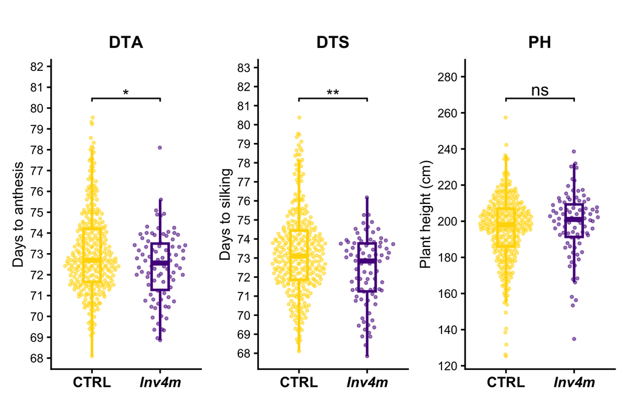

```r
results_tbl <- tibble(
  trait    = names(fits),
  estimate = sapply(fits, `[[`, "estimate"),
  se       = sapply(fits, `[[`, "se"),
  ci_lo    = sapply(fits, `[[`, "ci_lo"),
  ci_hi    = sapply(fits, `[[`, "ci_hi"),
  p_lmm    = sapply(fits, `[[`, "p"),
  p_perm   = sapply(perms, `[[`, "p_perm")
) |>
  mutate(star = case_when(p_lmm < 0.001 ~ "***",
                          p_lmm < 0.01  ~ "**",
                          p_lmm < 0.05  ~ "*",
                          TRUE          ~ "ns"))

# Figure 2's shared theme (verbatim where possible)
pheno_theme_panel <- ggpubr::theme_classic2(base_size = 14) +
  theme(
    plot.title       = element_text(size = 14, face = "bold", hjust = 0.5),
    plot.margin      = margin(t = 30, r = 5, b = 5, l = 5, unit = "pt"),
    axis.title.y     = element_text(size = 12),
    axis.title.x     = element_blank(),
    axis.text.x      = ggtext::element_markdown(size = 12, face = "bold",
                                                color = "black"),
    axis.text.y      = element_text(size = 10),
    legend.position  = "none"
  )

zeal_long <- df |>
  pivot_longer(cols = c(DTA_corr, DTS_corr, PH_corr),
               names_to = "trait", values_to = "value") |>
  filter(!is.na(value))

trait_lookup <- c(DTA_corr = "DTA",
                  DTS_corr = "DTS",
                  PH_corr  = "PH")
y_lab_pool   <- c(DTA_corr = "Days to anthesis",
                  DTS_corr = "Days to silking",
                  PH_corr  = "Plant height (cm)")
y_breaks_pool <- list(
  DTA_corr = scales::breaks_width(1),
  DTS_corr = scales::breaks_width(1),
  PH_corr  = scales::breaks_width(20)
)
star_lookup  <- setNames(
  results_tbl$star[match(TRAITS, results_tbl$trait)], TRAITS)

make_zeal_boxplot <- function(tr) {
  d <- zeal_long |> filter(trait == tr)
  ymax <- max(d$value, na.rm = TRUE)
  yrng <- diff(range(d$value, na.rm = TRUE))
  bracket_df <- tibble(group1 = "recurrent", group2 = "donor",
                       y.position = ymax + 0.08 * yrng,
                       label = star_lookup[[tr]])
  ggplot(d, aes(x = Inv4m, y = value, color = Inv4m)) +
    geom_boxplot(width = 0.25, linewidth = 1.0, alpha = 0,
                 outlier.shape = NA) +
    ggbeeswarm::geom_quasirandom(size = 0.8, alpha = 0.5) +
    scale_color_manual(values = c("recurrent" = "gold",
                                  "donor"     = "purple4")) +
    scale_x_discrete(labels = c("recurrent" = "CTRL",
                                "donor"     = "*Inv4m*")) +
    ggpubr::stat_pvalue_manual(bracket_df, tip.length = 0.01, size = 5,
                               bracket.size = 0.6, inherit.aes = FALSE) +
    scale_y_continuous(breaks = y_breaks_pool[[tr]],
                       expand = expansion(mult = c(0.05, 0.15))) +
    labs(title = trait_lookup[[tr]], y = y_lab_pool[[tr]], x = NULL) +
    pheno_theme_panel
}

box_plots <- lapply(TRAITS, make_zeal_boxplot)
panel_box <- cowplot::plot_grid(plotlist = box_plots, nrow = 1, ncol = 3,
                                align = "hv", axis = "tblr")
panel_box
```

## Per-ancestry breakdown

The pooled Inv4m effect averages across 5 races. Which races drive it? Promote `ancestry` to a fixed-effect interaction to extract per-ancestry contrasts:

$$\texttt{trait} \sim \text{Inv4m} \times \text{ancestry} + (1 \mid
\text{bc2} / \text{NIL})$$

```r
suppressPackageStartupMessages(library(emmeans))

per_race <- function(trait) {
  f <- as.formula(paste(trait, "~ Inv4m * ancestry + (1 | bc2/NIL)"))
  m <- suppressMessages(lmerTest::lmer(f, data = df |> mutate(ancestry = factor(ancestry))))
  aov <- anova(m, type = "III")
  em  <- emmeans(m, ~ Inv4m | ancestry, lmer.df = "satterthwaite")
  ct  <- as.data.frame(contrast(em, method = "revpairwise"))
  ct$p_adj_BH <- p.adjust(ct$p.value, method = "BH")
  ct$trait    <- trait
  list(model = m, anova = aov, contrast = ct |> arrange(estimate))
}

per_race_fits <- lapply(TRAITS, per_race)
names(per_race_fits) <- TRAITS

cat("Inv4m × ancestry interaction (does the effect vary by ancestry?):\n")
```

```
## Inv4m × ancestry interaction (does the effect vary by ancestry?):
```

```r
for (tr in names(per_race_fits)) {
  pp <- per_race_fits[[tr]]$anova["Inv4m:ancestry", "Pr(>F)"]
  cat(sprintf("  %s: p = %.3f\n", tr, pp))
}
```

```
##   DTA_corr: p = 0.249
##   DTS_corr: p = 0.339
##   PH_corr: p = 0.481
```

```r
per_race_tbl <- bind_rows(lapply(per_race_fits, `[[`, "contrast")) |>
  mutate(trait_label = recode(trait,
                              DTA_corr = "Days to anthesis",
                              DTS_corr = "Days to silking",
                              PH_corr  = "Plant height (cm)"),
         star = case_when(p_adj_BH < 0.001 ~ "***",
                          p_adj_BH < 0.01  ~ "**",
                          p_adj_BH < 0.05  ~ "*",
                          TRUE             ~ "ns"))

per_race_tbl |>
  select(trait_label, ancestry, estimate, SE, p.value, p_adj_BH, star) |>
  kable(digits = 3,
        caption = "Per-ancestry donor − recurrent contrast (BH-FDR over 5 races within each trait)")
```

Per-ancestry donor − recurrent contrast (BH-FDR over 5 races within each trait)

| trait_label | ancestry | estimate | SE | p.value | p_adj_BH | star |
| --- | --- | --- | --- | --- | --- | --- |
| Days to anthesis | Huehuetenango | -1.850 | 1.198 | 0.124 | 0.311 | ns |
| Days to anthesis | Durango | -1.096 | 0.401 | 0.007 | 0.034 | * |
| Days to anthesis | Chalco | -0.582 | 0.946 | 0.540 | 0.687 | ns |
| Days to anthesis | Nobogame | -0.211 | 0.524 | 0.687 | 0.687 | ns |
| Days to anthesis | Mesa-Central | 0.356 | 0.634 | 0.576 | 0.687 | ns |
| Days to silking | Huehuetenango | -1.878 | 1.370 | 0.172 | 0.430 | ns |
| Days to silking | Durango | -1.471 | 0.464 | 0.002 | 0.009 | ** |
| Days to silking | Chalco | -0.467 | 1.084 | 0.667 | 0.834 | ns |
| Days to silking | Nobogame | -0.446 | 0.602 | 0.460 | 0.766 | ns |
| Days to silking | Mesa-Central | 0.089 | 0.734 | 0.904 | 0.904 | ns |
| Plant height (cm) | Huehuetenango | -8.459 | 11.955 | 0.480 | 0.541 | ns |
| Plant height (cm) | Durango | -2.996 | 4.127 | 0.469 | 0.541 | ns |
| Plant height (cm) | Mesa-Central | 4.739 | 6.449 | 0.463 | 0.541 | ns |
| Plant height (cm) | Chalco | 5.756 | 9.387 | 0.541 | 0.541 | ns |
| Plant height (cm) | Nobogame | 7.174 | 5.277 | 0.176 | 0.541 | ns |

The Inv4m × ancestry interaction is **not significant** for either trait, so formally the data don’t reject “all races have the same Inv4m effect” — the per-ancestry table below is descriptive, not a hypothesis test the paper relies on.

### Per-ancestry boxplots (Figure 2 style)

[figure not shown]

```r
race_n <- df |>
  group_by(ancestry, Inv4m) |>
  summarise(n = sum(!is.na(DTS_corr) | !is.na(DTA_corr) | !is.na(PH_corr)),
            .groups = "drop") |>
  pivot_wider(names_from = Inv4m, values_from = n, values_fill = 0) |>
  mutate(ancestry_lab = sprintf("%s (n=%d/%d)", ancestry, recurrent, donor))
ancestry_lab_lookup <- setNames(race_n$ancestry_lab, race_n$ancestry)

zeal_long_race <- df |>
  pivot_longer(cols = c(DTA_corr, DTS_corr, PH_corr),
               names_to = "trait", values_to = "value") |>
  filter(!is.na(value)) |>
  mutate(ancestry_lab = factor(ancestry_lab_lookup[as.character(ancestry)],
                           levels = ancestry_lab_lookup[
                             c("Durango", "Nobogame", "Mesa-Central",
                               "Chalco", "Huehuetenango")]),
         trait_label = factor(recode(trait,
                                     DTA_corr = "Days to anthesis",
                                     DTS_corr = "Days to silking",
                                     PH_corr  = "Plant height (cm)"),
                              levels = c("Days to anthesis",
                                         "Days to silking",
                                         "Plant height (cm)")))

# star table keyed by ancestry × trait_label
star_df <- per_race_tbl |>
  mutate(ancestry_lab = ancestry_lab_lookup[as.character(ancestry)]) |>
  select(ancestry_lab, trait_label, star)

# y-position for star bracket per facet
bracket_df <- zeal_long_race |>
  group_by(ancestry_lab, trait_label) |>
  summarise(ymax = max(value, na.rm = TRUE),
            yrng = diff(range(value, na.rm = TRUE)),
            .groups = "drop") |>
  mutate(y.position = ymax + 0.10 * yrng,
         group1 = "recurrent", group2 = "donor") |>
  left_join(star_df, by = c("ancestry_lab", "trait_label")) |>
  rename(label = star)

p_per_race <- ggplot(zeal_long_race,
                     aes(x = Inv4m, y = value, color = Inv4m)) +
  geom_boxplot(width = 0.4, linewidth = 0.8, alpha = 0,
               outlier.shape = NA) +
  ggbeeswarm::geom_quasirandom(size = 0.7, alpha = 0.5) +
  scale_color_manual(values = c("recurrent" = "gold",
                                "donor"     = "purple4")) +
  scale_x_discrete(labels = c("recurrent" = "CTRL",
                              "donor"     = "*Inv4m*")) +
  ggpubr::stat_pvalue_manual(bracket_df, tip.length = 0.01, size = 4,
                             bracket.size = 0.5) +
  scale_y_continuous(expand = expansion(mult = c(0.05, 0.20))) +
  facet_grid(trait_label ~ ancestry_lab, scales = "free_y", switch = "y") +
  labs(x = NULL, y = NULL,
       title    = "Inv4m effect by donor ancestry",
       subtitle = "NC2025 BZea NIL panel; FDR adjusted per ancestry emmeans contrast (5 ancestry family per trait)") +
  theme_bw(base_size = 12) +
  theme(plot.title       = element_text(face = "bold"),
        strip.background = element_rect(fill = "grey92", color = NA),
        strip.text       = element_text(face = "bold"),
        axis.text.x      = ggtext::element_markdown(face = "bold"),
        legend.position  = "none",
        strip.placement  = "outside")
print(p_per_race)
```

```r
ggsave(file.path(paths$figures, "Zeal_Inv4m_per_race_boxplot.png"),
       p_per_race, width = 10, height = 8, dpi = 300)
ggsave(file.path(paths$figures, "Zeal_Inv4m_per_race_boxplot.svg"),
       p_per_race, width = 10, height = 8, fix_text_size = TRUE)
write.csv(per_race_tbl,
          file.path(paths$intermediate, "Zeal_Inv4m_per_race_contrasts.csv"),
          row.names = FALSE)
```

### Ancestry centered boxplot

The pooled boxplot above looks flat because `ancestry` carries ~20% of the total variance — mexicana races differ in baseline flowering by several days, which dwarfs the ~0.9 day Inv4m shift on the raw scale. Subtract each ancestry’s mean and the within ancestry contrast becomes visible:

$$\tilde{y}_{ij} = y_{ij} - \overline{y}_{\text{ancestry}=j}$$

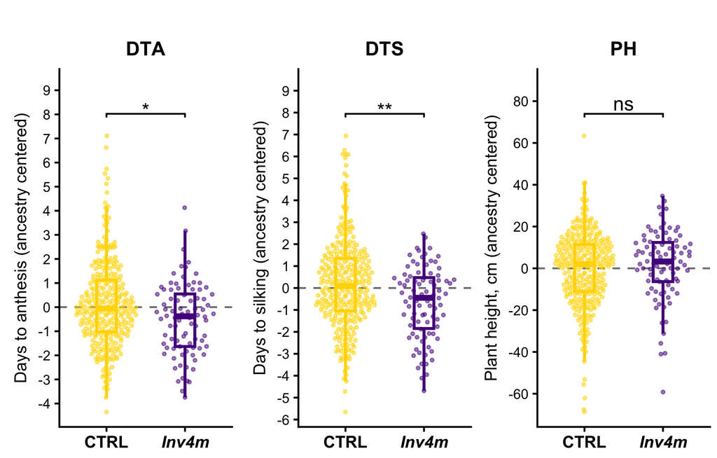

```r
zeal_resid <- df |>
  group_by(ancestry) |>
  mutate(DTA_resid = DTA_corr - mean(DTA_corr, na.rm = TRUE),
         DTS_resid = DTS_corr - mean(DTS_corr, na.rm = TRUE),
         PH_resid  = PH_corr  - mean(PH_corr,  na.rm = TRUE)) |>
  ungroup() |>
  pivot_longer(cols = c(DTA_resid, DTS_resid, PH_resid),
               names_to = "trait", values_to = "value") |>
  filter(!is.na(value))

resid_lookup <- c(DTA_resid = "DTA",
                  DTS_resid = "DTS",
                  PH_resid  = "PH")
y_lab_resid <- c(DTA_resid = "Days to anthesis (ancestry centered)",
                 DTS_resid = "Days to silking (ancestry centered)",
                 PH_resid  = "Plant height, cm (ancestry centered)")
y_breaks_resid <- list(
  DTA_resid = scales::breaks_width(1),
  DTS_resid = scales::breaks_width(1),
  PH_resid  = scales::breaks_width(20)
)
star_lookup_resid <- setNames(
  results_tbl$star[match(TRAITS, results_tbl$trait)],
  c("DTA_resid", "DTS_resid", "PH_resid"))

make_resid_boxplot <- function(tr) {
  d <- zeal_resid |> filter(trait == tr)
  ymax <- max(d$value, na.rm = TRUE)
  yrng <- diff(range(d$value, na.rm = TRUE))
  bracket_df <- tibble(group1 = "recurrent", group2 = "donor",
                       y.position = ymax + 0.08 * yrng,
                       label = star_lookup_resid[[tr]])
  ggplot(d, aes(x = Inv4m, y = value, color = Inv4m)) +
    geom_hline(yintercept = 0, linetype = "dashed", color = "grey50") +
    geom_boxplot(width = 0.25, linewidth = 1.0, alpha = 0,
                 outlier.shape = NA) +
    ggbeeswarm::geom_quasirandom(size = 0.8, alpha = 0.5) +
    scale_color_manual(values = c("recurrent" = "gold",
                                  "donor"     = "purple4")) +
    scale_x_discrete(labels = c("recurrent" = "CTRL",
                                "donor"     = "*Inv4m*")) +
    ggpubr::stat_pvalue_manual(bracket_df, tip.length = 0.01, size = 5,
                               bracket.size = 0.6, inherit.aes = FALSE) +
    scale_y_continuous(breaks = y_breaks_resid[[tr]],
                       expand = expansion(mult = c(0.05, 0.15))) +
    labs(title = resid_lookup[[tr]], y = y_lab_resid[[tr]],
         x = NULL) +
    pheno_theme_panel
}

resid_plots <- lapply(c("DTA_resid", "DTS_resid", "PH_resid"),
                      make_resid_boxplot)
panel_resid <- cowplot::plot_grid(plotlist = resid_plots,
                                  nrow = 1, ncol = 3,
                                  align = "hv", axis = "tblr")
panel_resid
```

```r
ggsave(file.path(paths$figures, "Zeal_Inv4m_flowering_boxplot_ancResid.png"),
       panel_resid, width = 7.2, height = 4.6, dpi = 300)
ggsave(file.path(paths$figures, "Zeal_Inv4m_flowering_boxplot_ancResid.svg"),
       panel_resid, width = 7.2, height = 4.6, fix_text_size = TRUE)
```

The *Inv4m* boxes now sit visibly below the B73 boxes — same data, same LMM contrast (−0.88 d / −0.61 d), but the ancestry stratification is no longer masking it. The dashed line is the within-ancestry mean (= zero by construction).

### Lineage corrected boxplot (ancestry + bc2 BLUPs subtracted, NIL preserved)

Subtract the upper random effect BLUPs (ancestry + bc2) but **keep** the NIL random effect, so each NIL line still contributes its own deviation to the visual spread:

$$\tilde{y}_{ij} = y_{ij} - \hat{u}_{\text{ancestry}} -
\hat{u}_{\text{bc2}}
= X\beta + \hat{u}_{\text{NIL}} + \varepsilon$$

```r
m_dts <- parsim_fits[["DTS_corr"]]$model
m_dta <- parsim_fits[["DTA_corr"]]$model
m_ph  <- parsim_fits[["PH_corr"]]$model

# IMPORTANT: predict()/residuals() return values only for rows the model
# actually fitted (NA-omitted). Align by the original row indices stored
# in model.frame() to avoid silent recycling.
#
# Lineage corrected = subtract ancestry + bc2 BLUPs; KEEP NIL BLUP.
#   y - ancestry_BLUP - bc2_BLUP
# = X*beta + NIL_BLUP + residual
# = predict(m, re.form = ~(1 | NIL:bc2:ancestry)) + residuals(m)
# (the deepest random effect grouping name from the slash form)
add_lmm_resid <- function(d, model, target_col, out_col) {
  rows_used <- as.integer(rownames(model.frame(model)))
  d[[out_col]] <- NA_real_
  d[[out_col]][rows_used] <-
    predict(model, re.form = ~(1 | NIL:bc2:ancestry)) + residuals(model)
  d
}

df_lmm <- df |>
  add_lmm_resid(m_dts, "DTS_corr", "DTS_lmm_resid") |>
  add_lmm_resid(m_dta, "DTA_corr", "DTA_lmm_resid") |>
  add_lmm_resid(m_ph,  "PH_corr",  "PH_lmm_resid")

# sanity check: donor - recurrent mean of residuals should equal the LMM beta
sanity <- df_lmm |>
  group_by(Inv4m) |>
  summarise(DTA_mean = mean(DTA_lmm_resid, na.rm = TRUE),
            DTS_mean = mean(DTS_lmm_resid, na.rm = TRUE),
            PH_mean  = mean(PH_lmm_resid,  na.rm = TRUE),
            .groups = "drop")
cat("residualized mean per arm:\n"); print(sanity)
```

```
## residualized mean per arm:
```

```
## # A tibble: 2 × 4
##   Inv4m     DTA_mean DTS_mean PH_mean
##   <fct>        <dbl>    <dbl>   <dbl>
## 1 recurrent     73.6     73.8    199.
## 2 donor         72.9     72.9    201.
```

```r
cat(sprintf("residualized donor - recurrent: DTA = %+.3f (beta %+.3f), DTS = %+.3f (beta %+.3f), PH = %+.3f (beta %+.3f)\n",
            diff(sanity$DTA_mean), fixef(m_dta)["Inv4mdonor"],
            diff(sanity$DTS_mean), fixef(m_dts)["Inv4mdonor"],
            diff(sanity$PH_mean),  fixef(m_ph)["Inv4mdonor"]))
```

```
## residualized donor - recurrent: DTA = -0.661 (beta -0.613), DTS = -0.916 (beta -0.881), PH = +1.732 (beta +1.606)
```

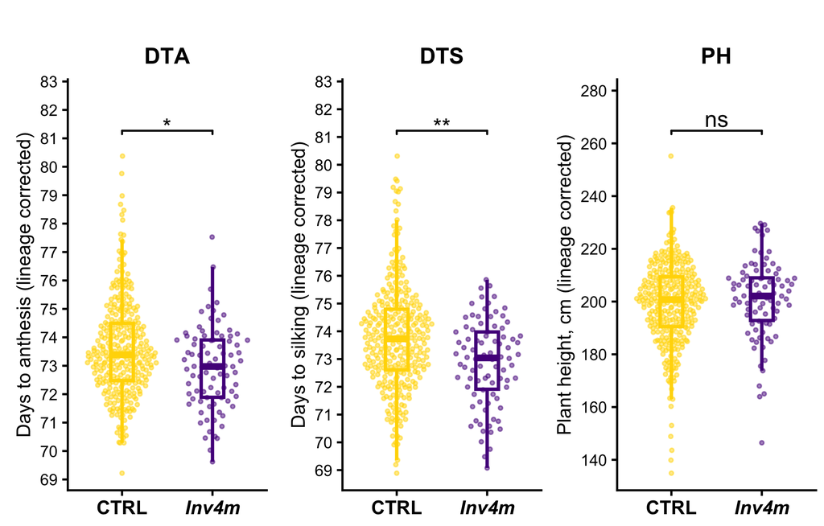

```r
zeal_lmm <- df_lmm |>
  pivot_longer(cols = c(DTA_lmm_resid, DTS_lmm_resid, PH_lmm_resid),
               names_to = "trait", values_to = "value") |>
  filter(!is.na(value))

lmm_lookup <- c(DTA_lmm_resid = "DTA",
                DTS_lmm_resid = "DTS",
                PH_lmm_resid  = "PH")
y_lab_lookup <- c(DTA_lmm_resid = "Days to anthesis (lineage corrected)",
                  DTS_lmm_resid = "Days to silking (lineage corrected)",
                  PH_lmm_resid  = "Plant height, cm (lineage corrected)")
y_breaks_lookup <- list(
  DTA_lmm_resid = scales::breaks_width(1),
  DTS_lmm_resid = scales::breaks_width(1),
  PH_lmm_resid  = scales::breaks_width(20)
)
star_lookup_lmm <- setNames(
  results_tbl$star[match(c("DTA_corr", "DTS_corr", "PH_corr"), results_tbl$trait)],
  c("DTA_lmm_resid", "DTS_lmm_resid", "PH_lmm_resid"))

make_lmm_boxplot <- function(tr) {
  d <- zeal_lmm |> filter(trait == tr)
  ymax <- max(d$value, na.rm = TRUE)
  yrng <- diff(range(d$value, na.rm = TRUE))
  bracket_df <- tibble(group1 = "recurrent", group2 = "donor",
                       y.position = ymax + 0.08 * yrng,
                       label = star_lookup_lmm[[tr]])
  ggplot(d, aes(x = Inv4m, y = value, color = Inv4m)) +
    geom_boxplot(width = 0.25, linewidth = 1.0, alpha = 0,
                 outlier.shape = NA) +
    ggbeeswarm::geom_quasirandom(size = 0.8, alpha = 0.5) +
    scale_color_manual(values = c("recurrent" = "gold",
                                  "donor"     = "purple4")) +
    scale_x_discrete(labels = c("recurrent" = "CTRL",
                                "donor"     = "*Inv4m*")) +
    ggpubr::stat_pvalue_manual(bracket_df, tip.length = 0.01, size = 5,
                               bracket.size = 0.6, inherit.aes = FALSE) +
    scale_y_continuous(breaks = y_breaks_lookup[[tr]],
                       expand = expansion(mult = c(0.05, 0.15))) +
    labs(title = lmm_lookup[[tr]], y = y_lab_lookup[[tr]],
         x = NULL) +
    pheno_theme_panel
}

lmm_plots <- lapply(c("DTA_lmm_resid", "DTS_lmm_resid", "PH_lmm_resid"),
                    make_lmm_boxplot)
panel_lmm <- cowplot::plot_grid(plotlist = lmm_plots,
                                nrow = 1, ncol = 3,
                                align = "hv", axis = "tblr")
panel_lmm
```

```r
ggsave(file.path(paths$figures, "Zeal_Inv4m_flowering_boxplot_lmmResid.png"),
       panel_lmm, width = 7.2, height = 4.6, dpi = 300)
ggsave(file.path(paths$figures, "Zeal_Inv4m_flowering_boxplot_lmmResid.svg"),
       panel_lmm, width = 7.2, height = 4.6, fix_text_size = TRUE)

# write the per-plot residualized values alongside raw + ancestry-centered
out <- df_lmm |>
  group_by(ancestry) |>
  mutate(DTS_anc_centered = DTS_corr - mean(DTS_corr, na.rm = TRUE),
         DTA_anc_centered = DTA_corr - mean(DTA_corr, na.rm = TRUE),
         PH_anc_centered  = PH_corr  - mean(PH_corr,  na.rm = TRUE)) |>
  ungroup() |>
  select(Plot, NIL, ancestry, bc2, Inv4m,
         DTA_corr, DTS_corr, PH_corr,
         DTA_anc_centered, DTS_anc_centered, PH_anc_centered,
         DTA_lmm_resid, DTS_lmm_resid, PH_lmm_resid)
write.csv(out,
          file.path(paths$intermediate, "Zeal_phenotypes_race_corrected.csv"),
          row.names = FALSE)
```

Each Inv4m arm now shows the spread of NIL line means around its arm mean. The donor − recurrent gap matches the LMM coefficient (within a small drift from BLUP shrinkage), and the within arm SD reflects the line to line variation the LMM weighs — not the artificially tight plot to plot noise that subtracting the NIL BLUP would produce.

## Forest plot

```r
unit_lookup <- c(DTA_corr = "d", DTS_corr = "d", PH_corr = "cm")
results_tbl <- results_tbl |>
  mutate(trait_label = recode(trait,
                              DTA_corr = "Days to anthesis",
                              DTS_corr = "Days to silking",
                              PH_corr  = "Plant height (cm)"),
         unit  = unit_lookup[trait],
         label = sprintf("%+.2f %s   p=%.3g %s", estimate, unit, p_lmm, star))

print(results_tbl |> select(trait, estimate, se, ci_lo, ci_hi, p_lmm, p_perm))
```

```
## # A tibble: 3 × 7
##   trait    estimate    se ci_lo   ci_hi   p_lmm   p_perm
##   <chr>       <dbl> <dbl> <dbl>   <dbl>   <dbl>    <dbl>
## 1 DTA_corr   -0.613 0.266 -1.13 -0.0917 0.0221  0.00599
## 2 DTS_corr   -0.881 0.306 -1.48 -0.281  0.00438 0.000999
## 3 PH_corr     1.61  2.68  -3.65  6.86   0.550   0.326
```

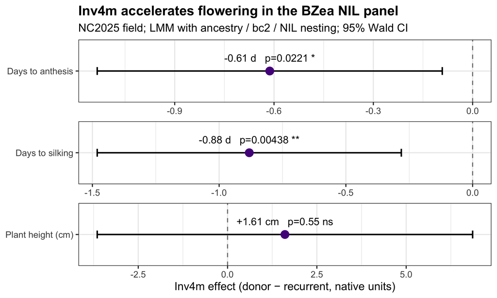

```r
# faceted forest, free x scale per trait so days and cm coexist honestly
p_forest <- ggplot(results_tbl,
                   aes(x = estimate, y = trait_label)) +
  geom_vline(xintercept = 0, linetype = "dashed", color = "grey50") +
  geom_errorbarh(aes(xmin = ci_lo, xmax = ci_hi),
                 height = 0.15, linewidth = 0.8) +
  geom_point(size = 4, color = "purple4") +
  geom_text(aes(label = label), nudge_y = 0.25, size = 4.2) +
  facet_wrap(~ trait_label, scales = "free", ncol = 1) +
  labs(
    x = "Inv4m effect (donor − recurrent, native units)",
    y = NULL,
    title    = "Inv4m accelerates flowering in the BZea NIL panel",
    subtitle = "NC2025 field; LMM with ancestry / bc2 / NIL nesting; 95% Wald CI"
  ) +
  theme_bw(base_size = 13) +
  theme(plot.title       = element_text(face = "bold"),
        strip.background = element_blank(),
        strip.text       = element_blank())
print(p_forest)
```

## Supplementary figure assembly

4 panel composite: (A) flowering boxplot with DTA + DTS as nested facets sharing a single days y axis, (B) flowering forest of LMM Inv4m effect (DTA + DTS in days), (C) PH boxplot alone (cm), (D) PH forest alone (cm). Mixed unit traits are kept on separate panels rather than forced onto a shared axis.

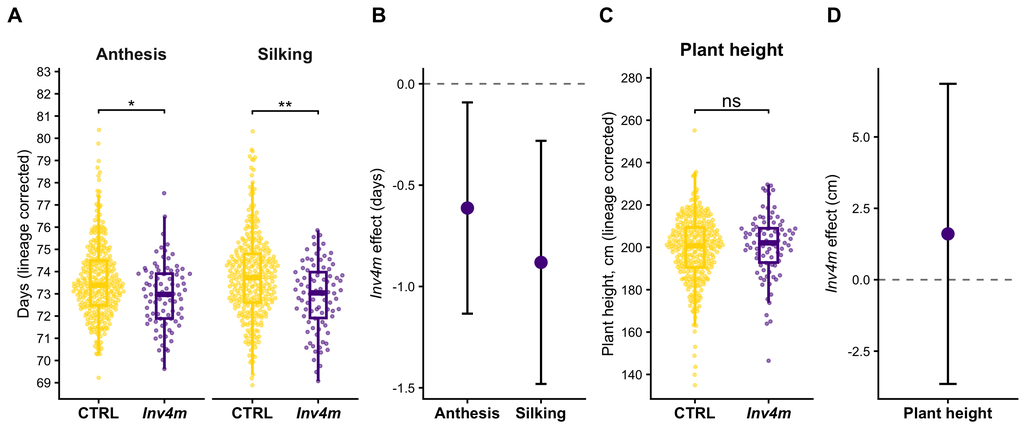

```r
suppressPackageStartupMessages(library(ggh4x))

forest_df <- results_tbl |>
  mutate(trait_short = factor(recode(trait,
                                     DTA_corr = "Anthesis",
                                     DTS_corr = "Silking",
                                     PH_corr  = "Plant height"),
                              levels = c("Anthesis", "Silking", "Plant height")))

## Panel A — flowering boxplot (anthesis + silking nested, shared y axis)
flow_long <- df_lmm |>
  pivot_longer(cols = c(DTA_lmm_resid, DTS_lmm_resid),
               names_to = "trait", values_to = "value") |>
  filter(!is.na(value)) |>
  mutate(trait_short = factor(recode(trait,
                                     DTA_lmm_resid = "Anthesis",
                                     DTS_lmm_resid = "Silking"),
                              levels = c("Anthesis", "Silking")))

flow_stars <- forest_df |> filter(trait %in% c("DTA_corr", "DTS_corr")) |>
  transmute(trait_short = factor(recode(trait,
                                        DTA_corr = "Anthesis",
                                        DTS_corr = "Silking"),
                                 levels = c("Anthesis", "Silking")),
            star = star)
flow_brackets <- flow_long |>
  group_by(trait_short) |>
  summarise(ymax = max(value, na.rm = TRUE),
            yrng = diff(range(value, na.rm = TRUE)),
            .groups = "drop") |>
  mutate(group1 = "recurrent", group2 = "donor",
         y.position = ymax + 0.08 * yrng) |>
  left_join(flow_stars, by = "trait_short") |>
  rename(label = star)

p_flow_box <- ggplot(flow_long,
                     aes(x = Inv4m, y = value, color = Inv4m)) +
  geom_boxplot(width = 0.25, linewidth = 1.0, alpha = 0,
               outlier.shape = NA) +
  ggbeeswarm::geom_quasirandom(size = 0.8, alpha = 0.5) +
  scale_color_manual(values = c("recurrent" = "gold",
                                "donor"     = "purple4")) +
  scale_x_discrete(labels = c("recurrent" = "CTRL",
                              "donor"     = "*Inv4m*")) +
  ggpubr::stat_pvalue_manual(flow_brackets, tip.length = 0.01, size = 5,
                             bracket.size = 0.6, inherit.aes = FALSE) +
  scale_y_continuous(breaks = scales::breaks_width(1),
                     expand = expansion(mult = c(0.05, 0.15))) +
  ggh4x::facet_nested(~ trait_short, scales = "fixed") +
  labs(x = NULL, y = "Days (lineage corrected)") +
  pheno_theme_panel +
  theme(strip.background  = element_blank(),
        strip.text        = element_text(size = 13, face = "bold"),
        ggh4x.facet.nestline = element_line(color = "black", linewidth = 0.5))

## Panel B — flowering forest (DTA + DTS, days)
forest_flow <- forest_df |> filter(trait %in% c("DTA_corr", "DTS_corr"))
p_forest_flow <- ggplot(forest_flow,
                        aes(x = trait_short, y = estimate)) +
  geom_hline(yintercept = 0, linetype = "dashed", color = "grey50") +
  geom_errorbar(aes(ymin = ci_lo, ymax = ci_hi),
                width = 0.15, linewidth = 0.8) +
  geom_point(size = 4, color = "purple4") +
  scale_y_continuous(breaks = scales::breaks_width(0.5)) +
  labs(x = NULL, y = "*Inv4m* effect (days)") +
  pheno_theme_panel +
  theme(axis.title.y = ggtext::element_markdown(size = 12))

## Panel C — PH boxplot alone (cm)
ph_long <- df_lmm |>
  filter(!is.na(PH_lmm_resid)) |>
  rename(value = PH_lmm_resid)
ph_star <- forest_df |> filter(trait == "PH_corr") |> pull(star)
ph_bracket <- tibble(group1 = "recurrent", group2 = "donor",
                     y.position = max(ph_long$value, na.rm = TRUE) +
                                  0.08 * diff(range(ph_long$value, na.rm = TRUE)),
                     label = ph_star)
p_ph_box <- ggplot(ph_long, aes(x = Inv4m, y = value, color = Inv4m)) +
  geom_boxplot(width = 0.25, linewidth = 1.0, alpha = 0,
               outlier.shape = NA) +
  ggbeeswarm::geom_quasirandom(size = 0.8, alpha = 0.5) +
  scale_color_manual(values = c("recurrent" = "gold",
                                "donor"     = "purple4")) +
  scale_x_discrete(labels = c("recurrent" = "CTRL",
                              "donor"     = "*Inv4m*")) +
  ggpubr::stat_pvalue_manual(ph_bracket, tip.length = 0.01, size = 5,
                             bracket.size = 0.6, inherit.aes = FALSE) +
  scale_y_continuous(breaks = scales::breaks_width(20),
                     expand = expansion(mult = c(0.05, 0.15))) +
  labs(title = "Plant height", x = NULL,
       y = "Plant height, cm (lineage corrected)") +
  pheno_theme_panel

## Panel D — PH forest alone (cm)
forest_ph <- forest_df |> filter(trait == "PH_corr")
p_forest_ph <- ggplot(forest_ph,
                      aes(x = trait_short, y = estimate)) +
  geom_hline(yintercept = 0, linetype = "dashed", color = "grey50") +
  geom_errorbar(aes(ymin = ci_lo, ymax = ci_hi),
                width = 0.15, linewidth = 0.8) +
  geom_point(size = 4, color = "purple4") +
  labs(x = NULL, y = "*Inv4m* effect (cm)") +
  pheno_theme_panel +
  theme(axis.title.y = ggtext::element_markdown(size = 12))

panel_supp <- cowplot::plot_grid(p_flow_box, p_forest_flow,
                                 p_ph_box,   p_forest_ph,
                                 nrow = 1, ncol = 4,
                                 align = "hv", axis = "tblr",
                                 rel_widths = c(1.6, 1, 1, 0.9),
                                 labels = c("A", "B", "C", "D"),
                                 label_size = 16,
                                 label_fontface = "bold")
panel_supp
```

```r
ggsave(file.path(paths$figures, "Zeal_Inv4m_flowering_supp.png"),
       panel_supp, width = 11, height = 4.6, dpi = 300)
ggsave(file.path(paths$figures, "Zeal_Inv4m_flowering_supp.svg"),
       panel_supp, width = 11, height = 4.6, fix_text_size = TRUE)
```

## Save outputs

```r
write.csv(results_tbl,
          file.path(paths$intermediate, "Zeal_Inv4m_flowering_lmm_results.csv"),
          row.names = FALSE)
write.csv(null_df,
          file.path(paths$intermediate, "Zeal_Inv4m_flowering_lmm_perm_null.csv"),
          row.names = FALSE)
write.csv(diag_tbl,
          file.path(paths$intermediate, "Zeal_Inv4m_flowering_lmm_level_diagnostic.csv"),
          row.names = FALSE)

# Figure 2-style boxplot (drop-in)
ggsave(file.path(paths$figures, "Zeal_Inv4m_flowering_boxplot.png"),
       panel_box, width = 4.8, height = 4.6, dpi = 300)
ggsave(file.path(paths$figures, "Zeal_Inv4m_flowering_boxplot.svg"),
       panel_box, width = 4.8, height = 4.6, fix_text_size = TRUE)

# Forest summary
ggsave(file.path(paths$figures, "Zeal_Inv4m_flowering_forest.png"),
       p_forest, width = 7, height = 3.2, dpi = 300)
ggsave(file.path(paths$figures, "Zeal_Inv4m_flowering_forest.svg"),
       p_forest, width = 7, height = 3.2, fix_text_size = TRUE)

# Permutation null
ggsave(file.path(paths$figures, "Zeal_Inv4m_flowering_perm_null.png"),
       p_null, width = 9, height = 3.6, dpi = 300)
```